# Exploratory data analysis

# Data preparation

The otu table with contaminants removed is convert to long format and a column for genus names is created by extracting the first word of the species designation.

```r
# convert decontaminated taxatable to long format
otu_table_long <- otu_table_decontam %>%
  pivot_longer(
    cols = where(is.numeric),
    names_to = "sample",
    values_to = "count"
    ) %>%
  rename(species = `#OTU ID`) %>%
  mutate(genus = str_extract(species, "\\w+"))
```

Counts are converted to relative abundance per sample. Separate data frames are generated for species and genus levels.

```r
species_abund_long <- otu_table_long %>%
  group_by(sample) %>%
  mutate(rel_abund = count / sum(count))

genus_abund_long <- species_abund_long %>%
  group_by(sample, genus) %>%
  summarise(
    count = sum(count),
    rel_abund = sum(rel_abund)
    )
# top 20 common genera in experiment
top_genus <- genus_abund_long %>%
  filter(str_detect(sample, "SYN")) %>%
  ungroup() %>%
  arrange(desc(rel_abund)) %>%
  distinct(genus) %>%
  slice_head(n = 30) %>%
  left_join(genus_abund_long, by = "genus")

# top 20 species in experiment
top_species <- species_abund_long %>%
  filter(str_detect(sample, "SYN")) %>%
  ungroup() %>%
  arrange(desc(rel_abund)) %>%
  distinct(species) %>%
  slice_head(n = 30) %>%
  left_join(species_abund_long, by = "species")
```

The data frame of bacterial properties was combined with the list of species from the analysis.

```r
species_properties <- bac_properties %>%
  right_join(species_abund_long, by = "species") %>%
  mutate(abs = if_else(is.na(abs), FALSE, abs))
```

Distribution of oxygen tolerance across all experimental and reference samples based on information from BacDive.

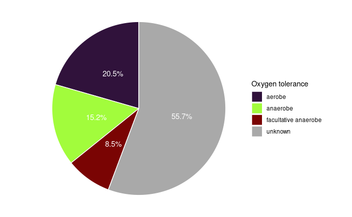

```r
species_properties %>%
  distinct(species, .keep_all = T) %>%
  count(`Oxygen tolerance`) %>%
  mutate(`Oxygen tolerance` = replace_na(`Oxygen tolerance`, "unknown"),
         perc = scales::percent(n / sum(n), accuracy = 0.1)) %>%
  ggplot(aes(x = "", y = n, fill = `Oxygen tolerance`)) +
    geom_col(colour = "white") +
    coord_polar(theta = "y") +
    geom_text(aes(label = perc), position = position_stack(vjust = 0.5), col = "white") +
    theme_void() +
    scale_fill_manual(
      values = c(viridisLite::turbo(n = length(levels(as.factor(species_properties$`Oxygen tolerance`)))), "darkgrey"))
```

## Colour legends

Legend for text-colour based on sample type.

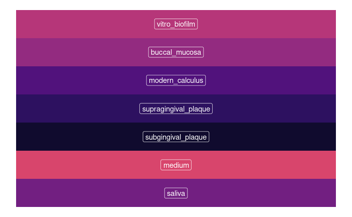

```r
col_seq <- 1:length(levels(as.factor(analysis_colours$env_col)))
env_col <- na.omit(unique(analysis_colours$env_col))
env_label <- filter(
  analysis_colours,
  Env == "saliva" |
  Env == "byoc_calculus" |
  Env == "medium" |
  Env == "buccal_mucosa" |
  Env == "subgingival_plaque" |
  Env == "supragingival_plaque" |
  Env == "modern_calculus" |
    Env == "vitro_biofilm"
  ) %>%
  .$Env %>%
  unique()
qplot(y= col_seq, x = 1, fill=factor(col_seq), geom="tile") +
  scale_fill_manual(values = env_col) +
  geom_label(aes(label = env_label), col = "white") +
  theme_void() +
  theme(legend.position="none")
```

Legend for text-colour based on treatment groups from the experiment.

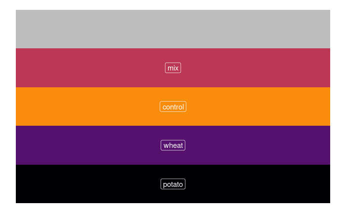

```r
col_seq <- 1:length(levels(as.factor(experiment_colours$treat_col)))
qplot(y= col_seq, x = 1, fill=factor(col_seq), geom="tile") +
  scale_fill_manual(values = na.omit(unique(experiment_colours$treat_col))) +
  geom_label(aes(label = unique(experiment_colours$treatment)), col = "white") +
  theme_void() +
  theme(legend.position="none")
```

# Within the experiment

Plotting relative species and genus abundances across experimental samples only. Samples are ordered from left to right by sampling day.

## Genus composition

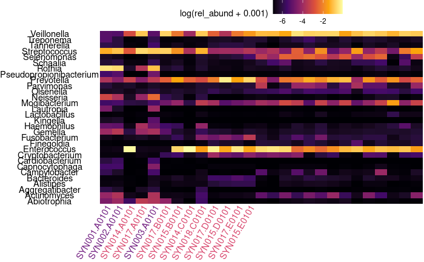

```r
#genus_abund_long
top_genus %>%
  filter(sample %in% experiment_metadata$`#SampleID`) %>%
  ggplot(aes(x = sample, y = genus, fill = log(rel_abund + 0.001))) +
    geom_tile() +
    theme_void() +
    scale_x_discrete(limits = rev(day_order)) + # reverse day_order vector
    #my_scale2 +
    theme(
      legend.position = "top",
      axis.text = element_text(),
      axis.text.x = element_text(
        angle = 60,
        hjust = 1,
        vjust = 1,
        colour = rev(experiment_colours$env_col)
        )
      ) +
    scale_fill_viridis_c(option = "B")
```

## Species composition

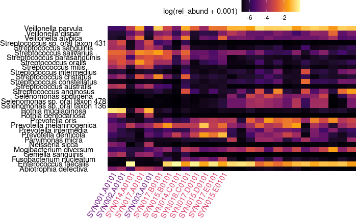

```r
top_species %>%
  filter(sample %in% experiment_metadata$`#SampleID`) %>%
  ggplot(aes(x = sample, y = species, fill = log(rel_abund + 0.001))) +
    geom_tile() +
    theme_void() +
    scale_x_discrete(limits = rev(day_order)) + # reverse day_order vector
    #my_scale2 +
    theme(
      legend.position = "top",
      axis.text = element_text(),
      axis.text.x = element_text(
        angle = 60,
        hjust = 1,
        vjust = 1,
        colour = rev(experiment_colours$env_col)
        )
      ) +
    scale_fill_viridis_c(option = "B")
```

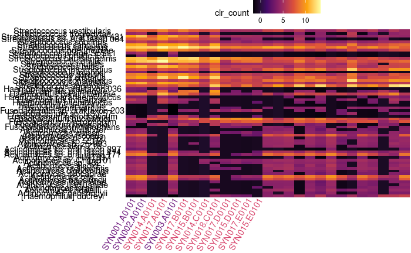

```r
clr_byoc_long %>%
  filter(#sample %in% experiment_metadata$`#SampleID`,
         str_detect(species, "Streptococcus|Actinomyces|Fusobacterium|Haemo")) %>% # early colonisers
  ggplot(aes(x = sample, y = species, fill = clr_count)) +
    geom_tile() +
    theme_void() +
    scale_x_discrete(limits = rev(day_order)) + # reverse day_order vector
    #my_scale2 +
    theme(
      legend.position = "top",
      axis.text = element_text(),
      axis.text.x = element_text(
        angle = 60,
        hjust = 1,
        vjust = 1,
        colour = rev(experiment_colours$env_col)
        )
      ) +
    scale_fill_viridis_c(option = "B")
```

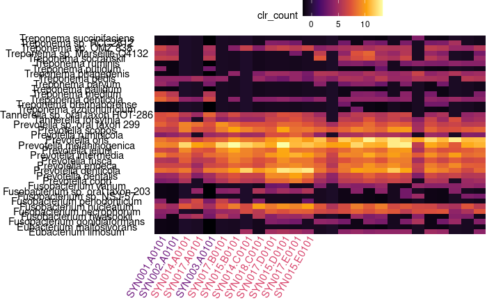

```r
clr_byoc_long %>%
  filter(#sample %in% experiment_metadata$`#SampleID`,
         str_detect(species, "Fusobacterium|Eubacterium|Treponema|Tannerella|Prevotella")) %>% # Late colonisers
  ggplot(aes(x = sample, y = species, fill = clr_count)) +
    geom_tile() +
    theme_void() +
    scale_x_discrete(limits = rev(day_order)) + # reverse day_order vector
    #my_scale2 +
    theme(
      legend.position = "top",
      axis.text = element_text(),
      axis.text.x = element_text(
        angle = 60,
        hjust = 1,
        vjust = 1,
        colour = rev(experiment_colours$env_col)
        )
      ) +
    scale_fill_viridis_c(option = "B")
```

Decrease in oral streptococci over the course of the experiment is expected in biofilm growth. *Actinomyces* spp. were more abundant in saliva and in the final calculus product than early biofilm samples.

### Oxygen tolerance

```r
no_match <- unique(filter(species_properties, is.na(`Oxygen tolerance`))$species) # which species had no match?
```

Proportional distribution of oxygen tolerances across experimental samples. Data on oxygen tolerance obtained from [BacDive](https://bacdive.dsmz.de/). A total of **629** out of **1129** (55.7%) species did not have a match on BacDive.

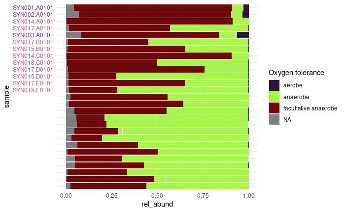

```r
species_properties %>%
  filter(sample %in% experiment_metadata$`#SampleID`) %>%
  ggplot(aes(y = sample, x = rel_abund, fill = `Oxygen tolerance`)) +
    geom_col() +
    theme_minimal() +
    #theme(axis.text.x = element_text(angle = 90)) +
    scale_y_discrete(limits = day_order) +
    scale_fill_manual(
      values = viridisLite::turbo(n = length(levels(as.factor(species_properties$`Oxygen tolerance`))))) +
  theme(
    axis.text.y = element_text(colour = experiment_colours$env_col)
  )
```

Generally an increase of anaerobes over the course of the experiment, at the expense of facultative anaerobes. Low proportion of aerobes throughout the experiment.

### Amylase-binding species

Relative abundance of ABS per sample. Different treatments indicated by text colour.

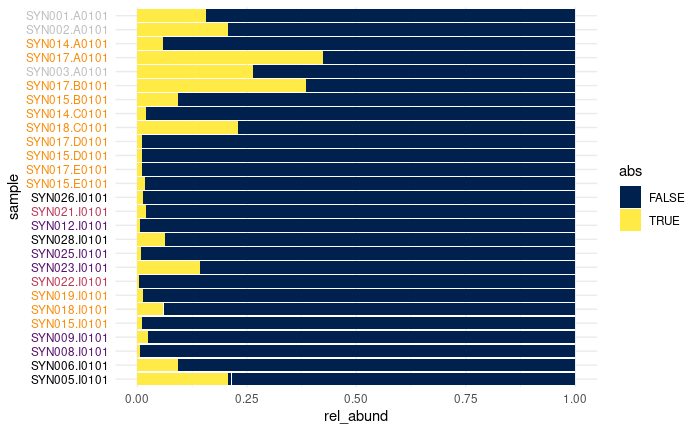

```r
species_properties %>%
  filter(str_detect(sample, "SYN")) %>%#,
         #str_detect(sample, "SYN00[1-3]", negate = T)) %>%
  ggplot(aes(y = sample, x = rel_abund, fill = abs)) +
    geom_col() +
    theme_minimal() +
    #theme(axis.text.x = element_text(angle = 90)) +
    scale_y_discrete(limits = day_order) +
    scale_fill_viridis_d(option = "E") +
    theme(
      axis.text.y = element_text(
        colour = experiment_colours %>%
          arrange(desc(day)) %>%
          .$treat_col))
```

```r
experiment_metadata %>%
  dplyr::select(`#SampleID`, treatment)
```

| #SampleID | treatment |
| --- | --- |
| SYN001.A0101 | NA |
| SYN002.A0101 | NA |
| SYN003.A0101 | NA |
| SYN015.B0101 | control |
| SYN015.D0101 | control |
| SYN015.E0101 | control |
| SYN017.A0101 | control |
| SYN017.B0101 | control |
| SYN018.C0101 | control |
| SYN005.I0101 | potato |

[output cut: 17 more lines]

The presence of ABS is unrelated to the presence of starch. The overall proportion of ABS decreases over the course of the experiment. The absence of amylase in the model may reduce the need for species capable of starch hydrolysis, especially when sucrose was available in all samples.

# Comparative samples

Looking at relative abundances at species and genus levels of calculus and plaque samples. Top 30 taxa (relative abundance) were plotted.

## Genus composition

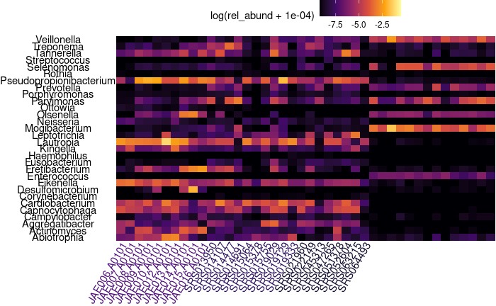

```r
genus_abund_long %>%
  filter(sample %in% filter(analysis_metadata, str_detect(Env, "calculus|plaque"))$`#SampleID`) %>%
  ungroup() %>%
  arrange(desc(rel_abund)) %>%
  distinct(genus) %>%
  slice_head(n = 30) %>% # top 30 species across all samples
  left_join(species_abund_long, by = "genus") %>% # recombine with samples
  filter(sample %in% filter(analysis_metadata, str_detect(Env, "calculus|plaque"))$`#SampleID`) %>% #need to filter out samples again
  ggplot(aes(x = sample, y = genus, fill = log(rel_abund + 0.0001))) +
    geom_tile() +
    theme_void() +
    #my_scale2 +
    theme(
      legend.position = "top",
      axis.text = element_text(),
      axis.text.x = element_text(
        angle = 60,
        hjust = 1,
        vjust = 1,
        colour = filter(
            analysis_colours, str_detect(Env, "calculus|plaque")
            )$env_col %>%
          rev()
        )
      ) +
    scale_fill_viridis_c(option = "B")
```

## Species composition

Relative abundance

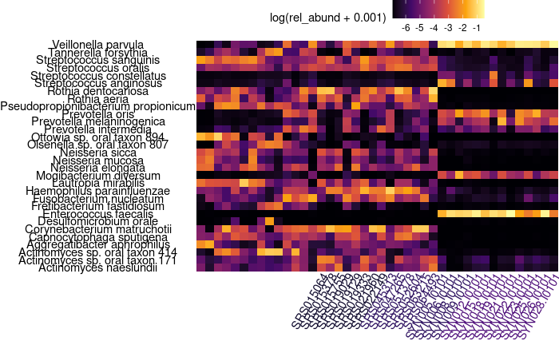

```r
# relative abundance
species_abund_long %>%
  filter(sample %in% filter(analysis_metadata, str_detect(Env, "calculus|plaque"))$`#SampleID`) %>%
  ungroup() %>%
  arrange(desc(rel_abund)) %>%
  distinct(species) %>%
  slice_head(n = 30) %>% # top 30 species across all samples
  left_join(species_abund_long, by = "species") %>% # recombine with samples
  filter(sample %in% filter(analysis_metadata, str_detect(Env, "calculus|plaque"))$`#SampleID`) %>% #need to filter out samples again
  ggplot(aes(x = sample, y = species, fill = log(rel_abund + 0.001))) +
    geom_tile() +
    theme_void() +
    #my_scale2 +
    theme(
      legend.position = "top",
      axis.text = element_text(),
      axis.text.x = element_text(
        angle = 60,
        hjust = 1,
        vjust = 1,
        colour = filter(
            analysis_colours, str_detect(Env, "calculus|plaque")
            )$env_col
        )
      ) +
    scale_fill_viridis_c(option = "B")
```

Centered ratio log-transform abundance ordered by PC1 loadings.

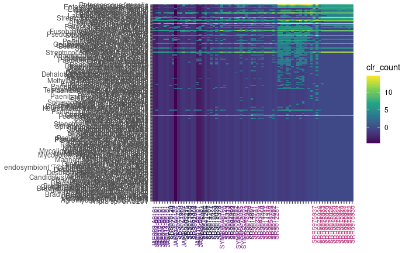

```r
# Top positive loadings on PC1
species_pos_pc1 +
    scale_fill_viridis_c() +
    theme(
      axis.title.y = element_blank(),
      axis.title.x = element_blank(),
      axis.text.x = element_text(
        angle = 90, size = 8, vjust = 0.5, hjust = 1,
        colour = analysis_colours %>%
          right_join(
            as_tibble(spca_species$x, rownames = "#SampleID"),
            by = "#SampleID") %>%
          arrange(PC1) %>%
          .$env_col
      )
      )
```

*Enterococcus faecalis*, *Enterococcus casseliflavus*, and *Enterococcus durans* are more abundant in the *in vitro* biofilm samples than *in vivo* samples of plaque and calculus. Conversely, *Neisseria* spp. and *Actinomyces* spp. are deficient in the *in vitro* samples.

### Early colonisers

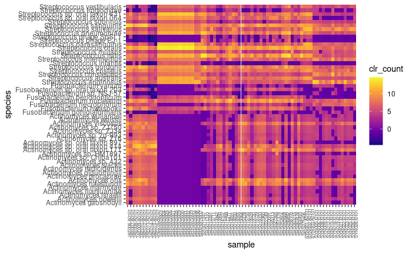

```r
clr_compar_long %>%
  filter(str_detect(species, "Streptococcus|Actinomyces|Fusobacterium")) %>%
  ggplot(aes(x = sample, y = species, fill = clr_count)) +
    geom_tile() +
    scale_fill_viridis_c(option = "C") +
    theme(axis.text.x = element_text(angle = 90, size = 6))
```